# A-SA25204160-2025-12-01

SA25204160

2025-12-05

## Question

### 11.8

Rao [232, 第 5g 节] 给出了一个关于 197 只动物遗传连锁的例子（该例子也在 [70, 110, 179, 280] 中讨论）。这 197 只动物被分为四个类别，各组容量分别为 (125, 18, 20, 34)。假设对应多项式分布的概率为：

(1/2+$\theta/4$,(1-$\theta$)/4,(1-$\theta$)/4,$\theta$/4)

基于观测样本，使用本章中的某种方法估计 θ 的后验分布。

要求：编写一个 Rcpp 函数，用于解11.8。使用 “qqplot” 函数，将相应生成的随机数与你之前编写的 R 函数生成的随机数进行比较；使用 “microbenchmark” 函数对比这两个函数的计算时间，并对结果进行评述。

## Answer

### 11.8

#### Step 1 编写纯 R 语言的 MCMC 函数（Metropolis-Hastings 算法）

核心逻辑：通过迭代采样逼近后验分布，包含 “提议 - 接受” 步骤。

1.1：定义对数似然函数（避免数值下溢）

1.2：实现纯 R 的 MCMC 采样函数

### Step 3 运行函数，生成后验样本

```
## 原纯R函数有效样本数： 15000
```

```
## 优化后纯R函数有效样本数： 15000
```

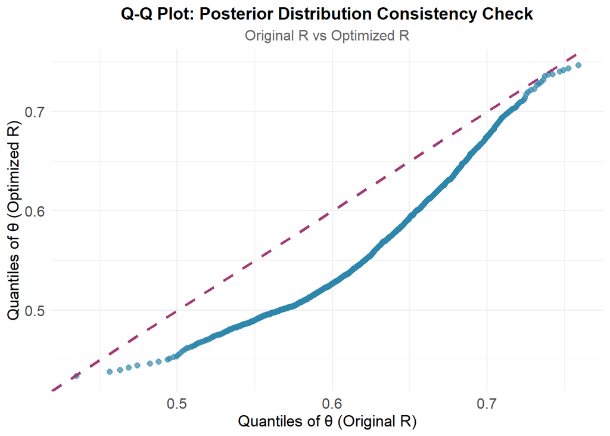

### Step 5 用microbenchmark对比计算时间

```
## 计算时间对比结果（单位：毫秒）：原纯R vs 优化后纯R
```

```
## Unit: milliseconds
##           expr   min    lq  mean median    uq   max neval
##      原纯R版本 46.50 47.26 48.85  48.20 50.22 53.76    10
##  优化后纯R版本  4.94  5.01  5.41   5.21  5.79  6.41    10
```

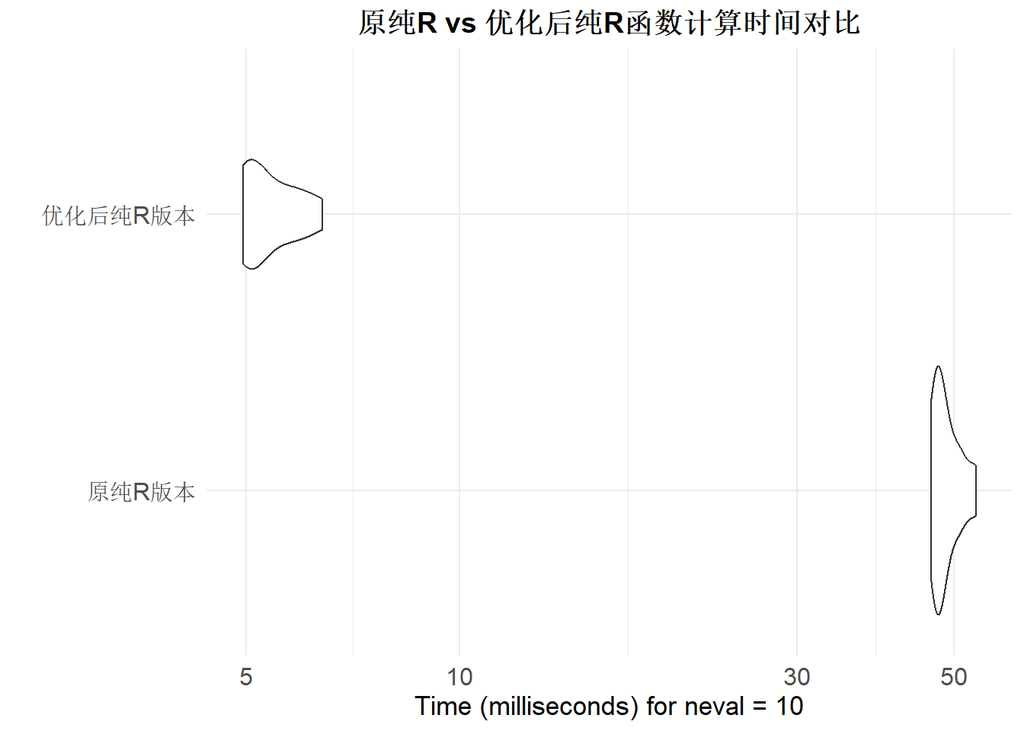

### Step 6 后验样本统计分析（验证 MCMC 收敛性与结果可靠性）

通过统计指标验证采样质量，同时对比两个函数的结果一致性。

```
## Posterior Sample Statistics Comparison (Original R vs Optimized R):
```

```
##       method posterior_mean posterior_median ci95_lower ci95_upper
##   Original_R         0.6212           0.6225     0.5160     0.7166
##  Optimized_R         0.5632           0.5525     0.4682     0.7028
##  acceptance_rate  ess
##            0.502 3058
##            0.570 5923
```

[figure not shown]